# Progetto Laboratorio di Statistica

### 5.4 Diagnostica dei residui

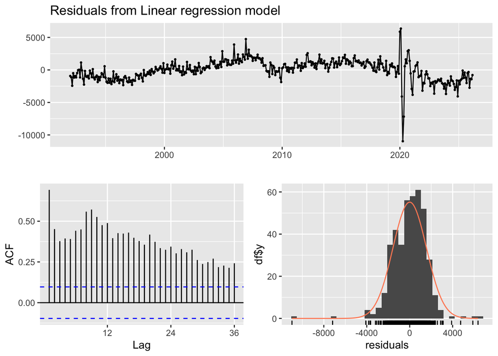

```
##
##  Breusch-Godfrey test for serial correlation of order up to 24
##
## data:  Residuals from Linear regression model
## LM test = 268, df = 24, p-value < 2.2e-16
```

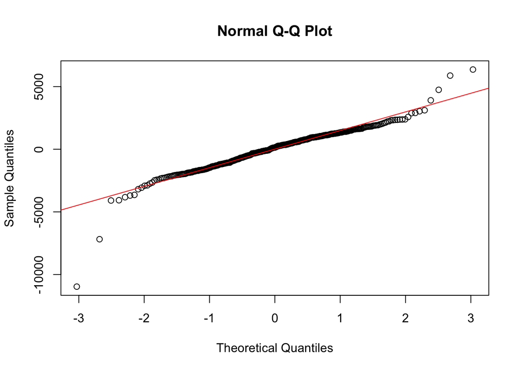

Il grafico dei residui nel tempo mostra una media prossima allo zero, segno che l’ipotesi di esogeneità degli errori è rispettata. È ben visibile lo shock 2020 testimoniando che la dummy Covid,essendo annuale, non riesce a riprodurre la caduta concentrata nei mesi del lockdown ma riesce a catturare il calo medio del 2020.

L’istogramma evidenzia una distribuzione quasi a campana, simmetrica e centrata sullo zero, complessivamente ben approssimata dalla densità normale sovrapposta; le code sono dovute essenzialmente alle osservazioni anomale del 2020. L’ipotesi di normalità dei residui può quindi ritenersi accettabile.

L’ACF dei residui ci dice che la quasi tutte le autocorrelazioni ai vari ritardi superano le bande di confidenza. I residui sono dunque fortemente autocorrelati non costituendo di conseguenza un processo white noise. Il modello cattura adeguatamente le componenti deterministiche ($R^2$ dell’86%) ma non cattura bene la dinamica di breve periodo, ossia la dipendenza del valore di ciascun mese da quelli immediatamente precedenti.

Dato che l’ipotesi di assenza di autocorrelazione tra i residui è violata avremo che gli intervalli prodotti dal modello di regressione tenderebbero a sottostimare/sovrastimare l’incertezza effettiva. Le stime dei coefficienti restano invece valide e correttamente interpretabili.Questo aspetto sarà determinante nel confronto tra modelli, dove potremmo preferire metodi in grado di trattare la componente autocorrelata per finalità previsive.

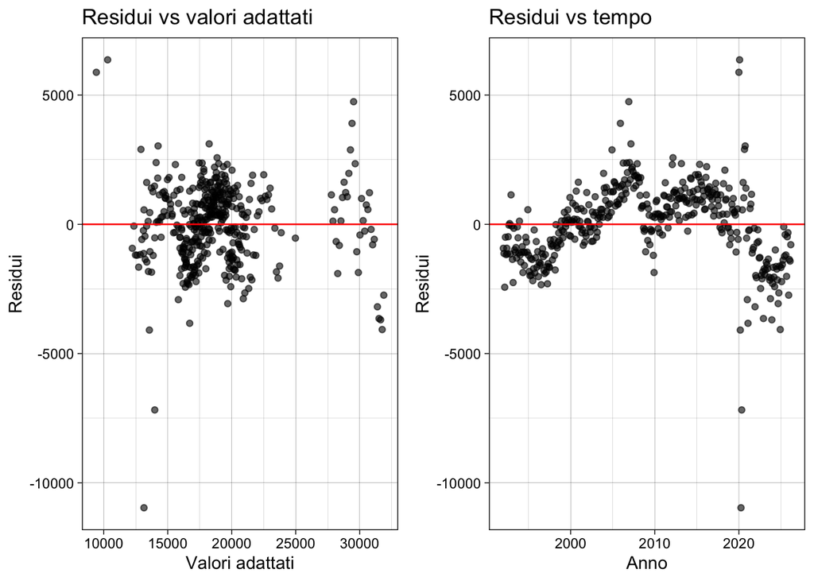

Esaminando i residui rispetto ai valori adattati notiamo che la nuvola centrale presenta un’ampiezza verticale sostanzialmente costante attorno allo zero, (non abbiamo la classica forma ad imbuto eteroschedastica).

Il grafico residui contro tempo evidenzia che i residui non oscillano casualmente attorno allo zero ma disegnano ondulazioni.E’ la manifestazione dell’autocorrelazione, dopo il 2020 i residui restano negativi. Questo ci dice che il trend lineare stimato sull’intero campione risulta ottimistico per dati recenti. Nel complesso l’ipotesi di omoschedasticità può ritenersi accettabile, con l’eccezione del 2020.

### 5.5 Valutazione dell’accuratezza

Per scegliere il modello da impiegare nella previsione finale dividiamo la serie in un insieme di **training** (su cui i modelli vengono stimati/addestrati) e un insieme di **test** (gli ultimi 12 mesi, su cui ne misuriamo le metriche di accuratezza). Mettiamo a confronto **Seasonal Naive**, **Decomposizione STL (previsione)** e **Regressione**.

```r
h <- 12
n <- length(Vendite_Reali_CPI2)
train <- subset(Vendite_Reali_CPI2, end = n-h)
test  <- subset(Vendite_Reali_CPI2, start = n-h+1)
```

Calcoliamo le metriche di accuratezza sul test analizzando MAE, RMSE, MAPE e MASE.

```r
acc.snaive <- accuracy(fc.snaive, test)
acc.stl    <- accuracy(fc.stl,    test)
acc.reg    <- accuracy(fc.reg,    test)

tabella <- rbind(
  "Seasonal naïve" = acc.snaive["Test set", c("MAE","RMSE","MAPE","MASE")],
  "STL forecast"   = acc.stl["Test set",    c("MAE","RMSE","MAPE","MASE")],
  "Regressione"    = acc.reg["Test set",    c("MAE","RMSE","MAPE","MASE")]
)
tabella
```

```
##                      MAE     RMSE     MAPE      MASE
## Seasonal naïve 1151.9785 1243.214 5.696262 1.1892745
## STL forecast    886.5394 1047.996 4.257546 0.9152417
## Regressione    1272.5579 1477.761 6.501965 1.3137577
```

Confrontiamo visivamente le tre previsioni con i valori effettivamente osservati nel periodo di test.

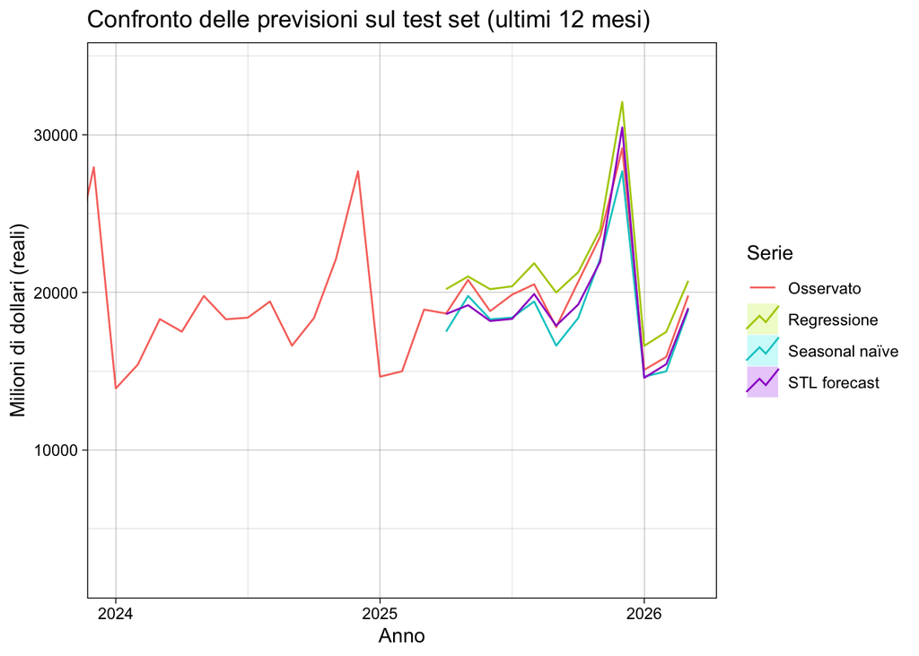

La **previsione con decomposizione STL** risulta il modello più accurato: presenta i valori più bassi delle metriche di accuratezza.

Il modello di **regressione** risulta invece il meno accurato in previsione, prevede peggio del seasonal naïve, nonostante l’ottimo adattamento ai dati (’$R^2$ dell’86%).

Il **seasonal naïve** si colloca nel mezzo superando la regressione.

Di conseguenza il modello selezionato per la previsione finale è **previsione con decomposizione STL**.

Possiamo inoltre valutare l’accuratezza tramite cross-validation su serie storiche. A differenza dello split fisso, questa procedura calcola l’errore di previsione a un passo lungo l’intera serie facendo poi la media dei risultati.

```r
e.snaive <- tsCV(Vendite_Reali_CPI2, snaive, h = 1, initial = 205)

fstl <- function(y, h) stlf(y, s.window = "periodic", robust = TRUE,
                            method = "rwdrift", h = h)
e.stl <- tsCV(Vendite_Reali_CPI2, fstl, h = 1, initial = 205)
rmse.cv <- c(
  "Seasonal naïve" = sqrt(mean(e.snaive^2, na.rm = TRUE)),
  "STL forecast"   = sqrt(mean(e.stl^2,    na.rm = TRUE))
)
rmse.cv
```

```
## Seasonal naïve   STL forecast
##       2874.193       1633.915
```

La cross-validation conferma nuovamente che la **decomposizione STL**, avendo un RMSE inferiore, è il modello da preferire.

### 5.6 Previsione finale + Scenario-Based

Selezionato STL come modello più accurato, procediamo alla previsione finale a 12 mesi sulla serie reale completa. Estendiamo la decomposizione con il metodo rwdrift (random walk con drift): la componente destagionalizzata viene proiettata lungo il suo trend di fondo, e su di essa viene riapplicato il profilo stagionale stimato.

```r
fc.finale <- forecast(stl.fit, method = "rwdrift", h = 12)
fc.finale
```

```
##          Point Forecast    Lo 80    Hi 80     Lo 95    Hi 95
## Apr 2026       19540.38 17987.98 21092.79 17166.184 21914.58
## May 2026       20145.16 17947.06 22343.26 16783.455 23506.87
## Jun 2026       19120.59 16425.21 21815.97 14998.363 23242.81
## Jul 2026       19276.77 16160.65 22392.89 14511.073 24042.46
## Aug 2026       20828.19 17340.05 24316.32 15493.548 26162.83
## Sep 2026       18799.12 14973.46 22624.78 12948.283 24649.97
## Oct 2026       20186.47 16049.32 24323.61 13859.243 26513.69
## Nov 2026       22919.72 18491.62 27347.81 16147.525 29691.91
## Dec 2026       31292.14 26589.82 35994.46 24100.563 38483.72
## Jan 2027       15504.02 10541.43 20466.61  7914.389 23093.65
## Feb 2027       16365.48 11154.47 21576.48  8395.934 24335.02
## Mar 2027       19926.03 14476.86 25375.21 11592.238 28259.83
```

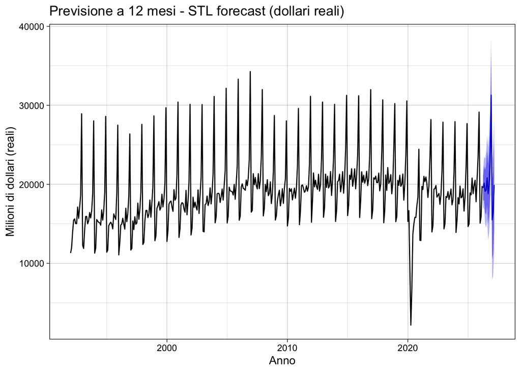

Il grafico mostra la serie storica reale prolungata dalla previsione con relative bande di confidenza. Trattandosi di intervalli di previsione (quindi relativi a una singola osservazione futura e non alla media) hanno un ampiezza maggiore poichè costituita da 2 fonti di incertezza: L’incertezza intrinseca (irriducibile) e l’incertezza di stima.

La previsione è espressa in dollari reali (a prezzi correnti, base = CPI dell’ultimo mese). Per tornare ai dollari nominali invertiamo la formula: poiché $x_t = \frac{y_t}{z_t}\times CPI_{base}$, si ha $y_t = \frac{x_t \times z_t}{CPI_{base}}$. Essendo il CPI futuro $z_t$ non noto lo proiettiamo sotto diversi scenari di inflazione

```r
cpi_ultimo <- cpi_base
prev_reale <- as.numeric(fc.finale$mean)

# 3 scenari
scenari <- c(basso = 0.02, centrale = 0.03, alto = 0.05
             )
mesi <- 1:12

nominale <- sapply(scenari, function(tasso) {
  cpi_futuro <- cpi_ultimo * (1 + tasso)^(mesi/12)   # CPI proiettato
  (prev_reale * cpi_futuro) / cpi_base                 # riconversione a nominale
})

nominale <- data.frame(Mese = mesi, Reale = round(prev_reale, 0), round(nominale, 0))
nominale
```

```
##    Mese Reale basso centrale  alto
## 1     1 19540 19573    19589 19620
## 2     2 20145 20212    20245 20310
## 3     3 19121 19215    19262 19355
## 4     4 19277 19404    19468 19593
## 5     5 20828 21001    21086 21256
## 6     6 18799 18986    19079 19263
## 7     7 20186 20421    20538 20769
## 8     8 22920 23224    23376 23677
## 9     9 31292 31760    31994 32458
## 10   10 15504 15762    15891 16147
## 11   11 16365 16665    16815 17114
## 12   12 19926 20325    20524 20922
```

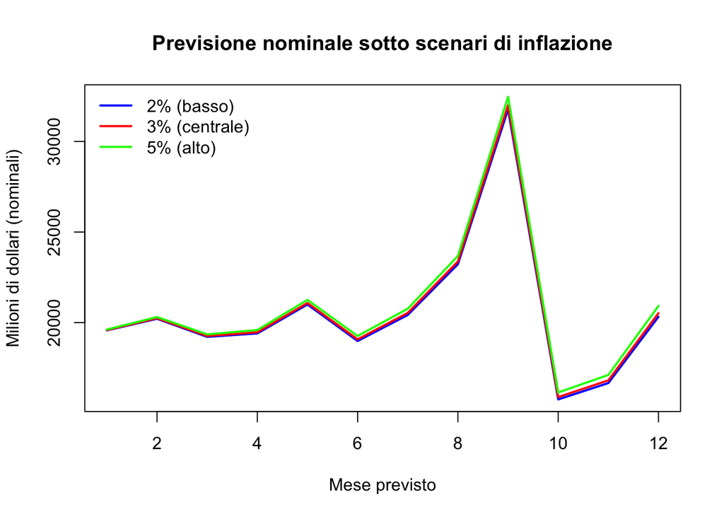

La previsione non fa riferimento ai mesi del calendario ma fa riferimento a 12 passi dell’orizzonte previsivo. Dato che il dataset finisce a Marzo 2026 il picco di dicembre corrisponde al 9° passo dell’orizzonte previsivo (non fa riferimento a settembre).

# 6. Conlusioni

Poiché il valore nominale del mercato è strettamente legato alla dinamica dei prezzi, la sola analisi storica dei volumi non consente di elaborare previsioni affidabili. Nonostante la rimozione di trend, stagionalità e inflazione abbia isolato il segnale reale del settore, la proiezione futura ha richiesto un approccio scenario-based sulle variabili macroeconomiche. Ne consegue che l’accuratezza del forecasting quantitativo dipende strettamente dall’integrazione del contesto economico generale.

# Riferimenti

Descrizione della Monthly Retail Trade Survey (MRTS): https://www.census.gov/retail/mrts/about_the_surveys.html

Serie vendite al dettaglio abbigliamento — `MRTSSM4481USN`: https://fred.stlouisfed.org/series/MRTSSM4481USN

Serie vendite al dettaglio liquori — `MRTSSM4453USN`: https://fred.stlouisfed.org/series/MRTSSM4453USN

Indice dei prezzi al consumo (CPI) — `CPIAUCNS`: https://fred.stlouisfed.org/series/CPIAUCNS

Individuazione di Outlier nelle serie storiche: https://robjhyndman.com/hyndsight/tsoutliers/

Decomposizione STL: https://otexts.com/fpp2/stl.html

Destagionalizzazione X11 e X13-SEATS: https://cran.r-project.org/package=seasonal